# Assignment 7

Emily K. Power

2023-01-29

## Data wrangling and plotting

1. Using the built-in `starwars` data set in the `dplyr` package, create a new tibble with the following modifications:
- It only includes the species that have more than 1 individual represented in the data set. (hint: first use `dplyr` to summarize the number of individuals per species in the data frame; then create a vector/tibble of those names; subset the species that are included in that vector)
- It only includes the columns that are not of type list (hint: use glimpse to check)

```r
library(dplyr)
species_counts <- starwars %>%
  count(species)
glimpse(species_counts)
```

```
## Rows: 38
## Columns: 2
## $ species <chr> "Aleena", "Besalisk", "Cerean", "Chagrian", "Clawdite", "Droid…
## $ n       <int> 1, 1, 1, 1, 1, 6, 1, 1, 1, 3, 35, 1, 1, 1, 2, 1, 2, 1, 1, 1, 1…
```

```r
species_names <- filter(species_counts, n>1)
species_names
```

```
## # A tibble: 9 × 2
##   species      n
##   <chr>    <int>
## 1 Droid        6
## 2 Gungan       3
## 3 Human       35
## 4 Kaminoan     2
## 5 Mirialan     2
## 6 Twi'lek      2
## 7 Wookiee      2
## 8 Zabrak       2
## 9 <NA>         4
```

```r
filtered_starwars <- filter(starwars, species %in% c("Droid", "Gungan", "Human", "Kaminoan", "Mirialan", "Twi'lek", "Wookiee", "Zabrak"))
head(filtered_starwars)
```

```
## # A tibble: 6 × 14
##   name         height  mass hair_…¹ skin_…² eye_c…³ birth…⁴ sex   gender homew…⁵
##   <chr>         <int> <dbl> <chr>   <chr>   <chr>     <dbl> <chr> <chr>  <chr>
## 1 Luke Skywal…    172    77 blond   fair    blue       19   male  mascu… Tatooi…
## 2 C-3PO           167    75 <NA>    gold    yellow    112   none  mascu… Tatooi…
## 3 R2-D2            96    32 <NA>    white,… red        33   none  mascu… Naboo
## 4 Darth Vader     202   136 none    white   yellow     41.9 male  mascu… Tatooi…
## 5 Leia Organa     150    49 brown   light   brown      19   fema… femin… Aldera…
## 6 Owen Lars       178   120 brown,… light   blue       52   male  mascu… Tatooi…
## # … with 4 more variables: species <chr>, films <list>, vehicles <list>,
## #   starships <list>, and abbreviated variable names ¹hair_color, ²skin_color,
## #   ³eye_color, ⁴birth_year, ⁵homeworld
```

2. Clean your data set: only include observations/rows that do not have an `NA` in the height column. Then, use `dplyr` to print a summary table showing the mean, median, and standard deviation of height for **each species.**

```r
clean_starwars <- filtered_starwars[complete.cases(filtered_starwars[,2]),]

starwars_heights <- clean_starwars %>%
  group_by(species) %>%
  summarize(meanHeight = mean(height), medianHeight = median(height), sdHeight = sd(height))
starwars_heights
```

```
## # A tibble: 8 × 4
##   species  meanHeight medianHeight sdHeight
##   <chr>         <dbl>        <dbl>    <dbl>
## 1 Droid          131.           97    49.1
## 2 Gungan         209.          206    14.2
## 3 Human          177.          180    12.5
## 4 Kaminoan       221           221    11.3
## 5 Mirialan       168           168     2.83
## 6 Twi'lek        179           179     1.41
## 7 Wookiee        231           231     4.24
## 8 Zabrak         173           173     2.83
```

3. Create a box plot figure that shows the variation in heights among Star Wars species. Do the values in your summary table line up with the plot? Code so that each box plot (Species) is be filled with a different color. Change your axes labels so that species is capitalized and height is capitalized and shows units (cm). Use the theme_minimal option. Then look into the `annotate` or `geom_text` functions and add the text “p=1.2E-0.5” to the top right corner.

*For an extra (optional) challenge:* overlay the data points onto the box plots (hint: look into `geom_jitter` or `geom_point`). See if you can change the color of the points, depending on the gender or sex variables.

```r
library(ggplot2)
library(viridis)
cols <- viridis(11, option = "viridis")

p1 <- ggplot(data=clean_starwars, aes(x=species, y=height, fill=species)) +
  geom_boxplot() +
  scale_fill_manual(values=cols) +
  geom_jitter(data = clean_starwars, position = "jitter", aes(color=sex))
```

4. Using the same or a different built-in data set, create at least one additional (and different kind of) plot. Experiment with different arguments, features, and colors.

```r
data(iris)
glimpse(iris)
```

```
## Rows: 150
## Columns: 5
## $ Sepal.Length <dbl> 5.1, 4.9, 4.7, 4.6, 5.0, 5.4, 4.6, 5.0, 4.4, 4.9, 5.4, 4.…
## $ Sepal.Width  <dbl> 3.5, 3.0, 3.2, 3.1, 3.6, 3.9, 3.4, 3.4, 2.9, 3.1, 3.7, 3.…
## $ Petal.Length <dbl> 1.4, 1.4, 1.3, 1.5, 1.4, 1.7, 1.4, 1.5, 1.4, 1.5, 1.5, 1.…
## $ Petal.Width  <dbl> 0.2, 0.2, 0.2, 0.2, 0.2, 0.4, 0.3, 0.2, 0.2, 0.1, 0.2, 0.…
## $ Species      <fct> setosa, setosa, setosa, setosa, setosa, setosa, setosa, s…
```

```r
petal_sizes <- iris %>%
  group_by(Species) %>%
  summarize(meanPetal.Length = mean(Petal.Length), meanPetal.Width = mean(Petal.Width))  # create summary table of petal sizes
petal_sizes
```

```
## # A tibble: 3 × 3
##   Species    meanPetal.Length meanPetal.Width
##   <fct>                 <dbl>           <dbl>
## 1 setosa                 1.46           0.246
## 2 versicolor             4.26           1.33
## 3 virginica              5.55           2.03
```

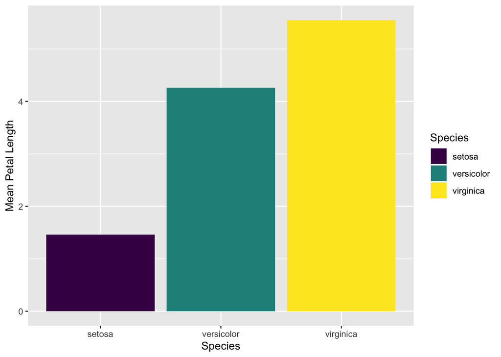

```r
library(viridis)
cols <- viridis(3, option = "viridis")  # create colors variable

p2 <- ggplot(petal_sizes, aes(x=Species, y=meanPetal.Length, fill=Species)) +  # select data for plot
  geom_bar(stat="identity") +  # create bar graph
  xlab("Species") +  # set x-axis label
  ylab("Mean Petal Length") +  # set y-axis label
  scale_fill_manual(values=cols)  # set colors of bars
p2
```

5. Finally, create a multi-panel figure with the graphs you created.

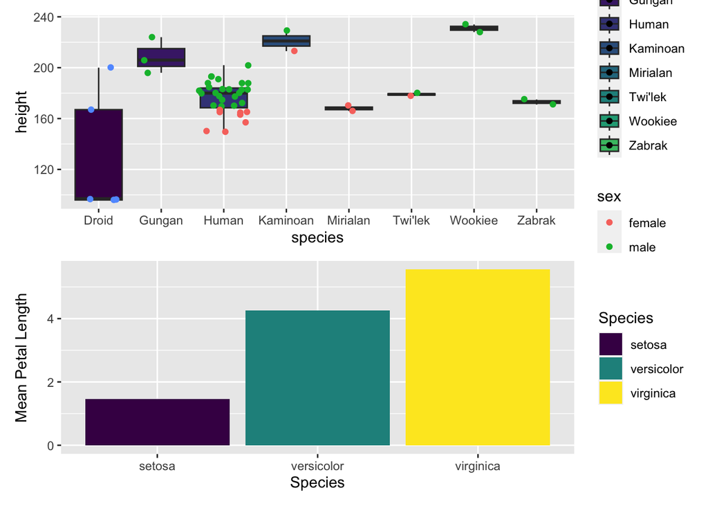

```r
library(patchwork)
p1 / p2
```